# R Notebook

I have downloaded csv files of closing prices of the following assets:

Crypto Assets: 1. Bitcoin (BTC) 2. Ethereum (ETH) 3. Tether (USDT) 4. USD Coin (USDC) 5. Binance Coin (BNB)

Traditional Assets 1. Vanguard 500 Index Fund (VOO) (Equities index) 2. Invesco QQQ Trust (QQQ) (Equities index) 3. Vanguard Total Bond Market Index Fund (VBTLX) (Bonds index) 4. abrdn Physical Gold Shares ETF (SGOL) (Metals) 5. Fidelity ZERO Large Cap Index Fund (FNILX) (Equity index large cap)

I’ll load these CSV files into a combined dataframe

```r
library(tidyverse)

BTC <- read.csv("BTC-USD.csv")
BTC <- tail(BTC[,5],250)

ETH <- read.csv("ETH-USD.csv")
ETH <- tail(ETH[,5],250)

USDT <- read.csv("USDT-USD.csv")
USDT <- tail(USDT[,5],250)

USDC <- read.csv("USDC-USD.csv")
USDC <- tail(USDC[,5],250)

BNB <- read.csv("BNB-USD.csv")
BNB <- tail(BNB[,5],250)

VOO <- read.csv("VOO.csv")
VOO <- tail(VOO[,5],250)

QQQ <- read.csv("QQQ.csv")
QQQ <- tail(QQQ[,5],250)

VBTLX <- read.csv("VBTLX.csv")
VBTLX <- tail(VBTLX[,5],250)

SGOL <- read.csv("SGOL.csv")
SGOL <- tail(SGOL[,5],250)

FNILX <- read.csv("FNILX.csv")
Date<- tail(FNILX[,1], 250)
FNILX <- tail(FNILX[,5],250)


data_combine <- data.frame(Date,BTC,ETH,USDT,USDC,BNB,VOO,QQQ,VBTLX,SGOL,FNILX)
```

I’m converting my DF into a time series object, and plotting the series

```r
require(xts)
library(xts)

data_combine[data_combine == "null"] <- ""
#View(data_combine)

df <- sapply(data_combine, as.numeric)
```

```
NAs introduced by coercion
```

```r
str(df)
```

```
 num [1:250, 1:11] NA NA NA NA NA NA NA NA NA NA ...
 - attr(*, "dimnames")=List of 2
  ..$ : NULL
  ..$ : chr [1:11] "Date" "BTC" "ETH" "USDT" ...
```

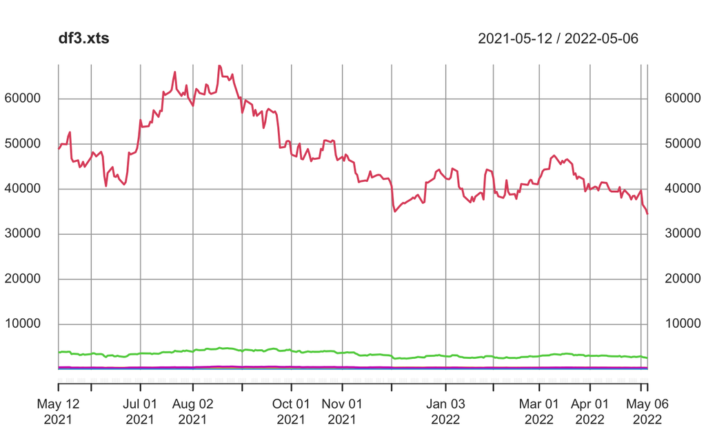

```r
#df1 <- null.omit(df)
#df2 <- na.omit(df1)
df3 <- data.frame(date=Date,df)


df3$date = as.POSIXct(df3$date,format="%Y-%m-%d", tz = "")
df3.xts <- xts(df3[,-1], order.by=df3[,1])

plot(df3.xts)
```

```r
#plot(df3.xts[,1:5])
#plot(df3.xts[,6:10])
```

Plotting returns

```r
#log return
return = diff (log(df3.xts)) # Log return calculation
return = return [-1] # removing the first empty observation, received after return calculation
summary (return)
```

```
     Index                          Date          BTC                  ETH
 Min.   :2021-05-13 00:00:00   Min.   : NA   Min.   :-0.1172325   Min.   :-0.1597866
 1st Qu.:2021-08-11 00:00:00   1st Qu.: NA   1st Qu.:-0.0204222   1st Qu.:-0.0227587
 Median :2021-11-08 00:00:00   Median : NA   Median :-0.0006967   Median :-0.0004521
 Mean   :2021-11-08 09:43:07   Mean   :NaN   Mean   :-0.0014104   Mean   :-0.0016801
 3rd Qu.:2022-02-07 00:00:00   3rd Qu.: NA   3rd Qu.: 0.0172475   3rd Qu.: 0.0223245
 Max.   :2022-05-06 00:00:00   Max.   : NA   Max.   : 0.1357643   Max.   : 0.1076220
                               NA's   :249
      USDT                 USDC                 BNB                 VOO                  QQQ
 Min.   :-1.606e-03   Min.   :-1.905e-03   Min.   :-0.172119   Min.   :-3.742e-02   Min.   :-5.168e-02
 1st Qu.:-1.480e-04   1st Qu.:-2.960e-04   1st Qu.:-0.023490   1st Qu.:-5.030e-03   1st Qu.:-8.014e-03
 Median :-1.400e-05   Median : 3.500e-05   Median : 0.001187   Median : 9.547e-04   Median : 9.538e-04
 Mean   :-2.020e-06   Mean   : 2.213e-06   Mean   :-0.001275   Mean   : 5.745e-05   Mean   :-9.801e-05
 3rd Qu.: 1.179e-04   3rd Qu.: 3.038e-04   3rd Qu.: 0.020950   3rd Qu.: 6.144e-03   3rd Qu.: 8.093e-03
 Max.   : 1.516e-03   Max.   : 2.058e-03   Max.   : 0.099814   Max.   : 2.988e-02   Max.   : 3.642e-02

     VBTLX                 SGOL                FNILX
 Min.   :-0.0120539   Min.   :-0.0312525   Min.   :-3.769e-02
 1st Qu.:-0.0019724   1st Qu.:-0.0038792   1st Qu.:-5.595e-03
 Median : 0.0000000   Median : 0.0005789   Median : 6.335e-04
 Mean   :-0.0004726   Mean   : 0.0001266   Mean   : 2.502e-05
 3rd Qu.: 0.0017762   3rd Qu.: 0.0049221   3rd Qu.: 6.593e-03
 Max.   : 0.0080322   Max.   : 0.0272862   Max.   : 2.949e-02
```

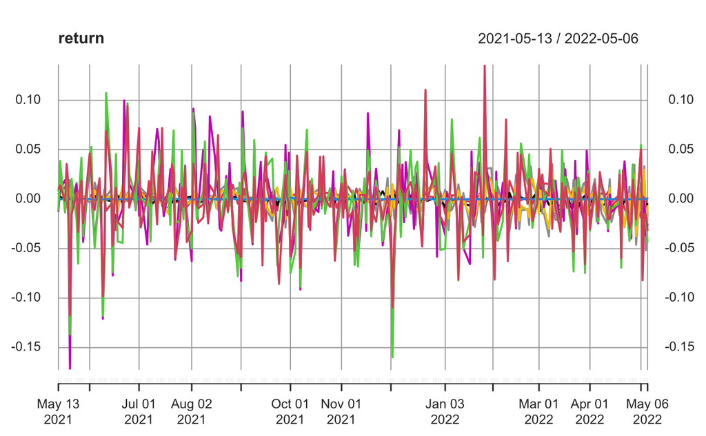

```r
plot(return)
```

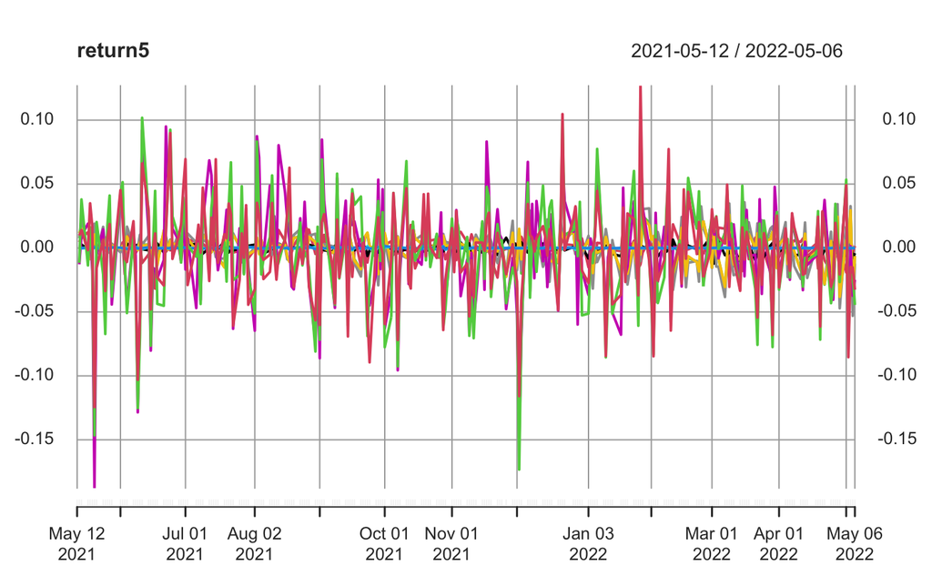

```r
library(PerformanceAnalytics)
return2 = Return.calculate(df3.xts, method="log")

return3 = diff (df3.xts) # differences
# the sane as
return4 = Return.calculate(df3.xts, method="difference")
#daily gain/loss (%)
return5 = diff(df3.xts)/df3.xts[-length(df3.xts)]

plot(return5)
```

```r
#Correlation #Chapter 2: Session 2
cor(df3.xts)
```

```
      Date         BTC         ETH        USDT        USDC         BNB         VOO         QQQ       VBTLX
Date     1          NA          NA          NA          NA          NA          NA          NA          NA
BTC     NA  1.00000000  0.90671311  0.08903524  0.06485922  0.78056530 -0.14868314  0.10283635  0.59173086
ETH     NA  0.90671311  1.00000000  0.13620456  0.03459228  0.93323270 -0.10719268  0.13492445  0.54354227
USDT    NA  0.08903524  0.13620456  1.00000000  0.31885266  0.20134394  0.18430236  0.20559853  0.19294027
USDC    NA  0.06485922  0.03459228  0.31885266  1.00000000  0.02155531 -0.12833478 -0.06415194  0.05679886
BNB     NA  0.78056530  0.93323270  0.20134394  0.02155531  1.00000000  0.08702599  0.29430850  0.48821419
VOO     NA -0.14868314 -0.10719268  0.18430236 -0.12833478  0.08702599  1.00000000  0.91830860  0.16364770
QQQ     NA  0.10283635  0.13492445  0.20559853 -0.06415194  0.29430850  0.91830860  1.00000000  0.49737441
VBTLX   NA  0.59173086  0.54354227  0.19294027  0.05679886  0.48821419  0.16364770  0.49737441  1.00000000
SGOL    NA -0.37242793 -0.39590260 -0.21042047 -0.03233021 -0.45472695 -0.29223828 -0.55208457 -0.72174758
FNILX   NA -0.01040719  0.04433632  0.19105769 -0.10045987  0.22413304  0.98046497  0.96729032  0.30394982
             SGOL       FNILX
Date           NA          NA
BTC   -0.37242793 -0.01040719
ETH   -0.39590260  0.04433632
USDT  -0.21042047  0.19105769
USDC  -0.03233021 -0.10045987
BNB   -0.45472695  0.22413304
VOO   -0.29223828  0.98046497
QQQ   -0.55208457  0.96729032
VBTLX -0.72174758  0.30394982
SGOL   1.00000000 -0.40622259
FNILX -0.40622259  1.00000000
```

## Part 2

```r
##ECONOMIC FACTOR MODEL
Traditional_Assets <- df3.xts[,7:11]
Crypto <- df3.xts[,1:6]
```

#### Factor Analysis

```r
## FACTOR Analysis

Traditional_Assets2 = as.matrix(Traditional_Assets)
Crypto2 = as.matrix(Crypto)
Indices = as.data.frame(diff(log(Traditional_Assets2)))  # log difference
names(Indices)[1]="Traditional_Assets"
Cryptocurrency = as.data.frame(diff(log(Crypto2))) #calculte log difference
names(Cryptocurrency)[1] = "Cryptocurrencies"
Indices_Cryptocurrency = cbind(Indices,Cryptocurrency) #View(Indices_Cryptocurrency)
berndt = as.matrix(df3.xts[,-1])
arFit = ar(cbind(Indices,Cryptocurrency)) # autoregressive model - by default selecting the complexity by AIC. Here it is AR(5)
```

```r
res = arFit$resid[4:1446,] # residuals of the AR (5) modle (the interpretations of the residuals is that they are unexpected shocks)
lmfit = lm(berndt[4:1446,2:9]~res[,1]+res[,2]) #fit a regression Y is a set of teh stock returns and X1 and X2 - residuals from the AR modles
slmfit = summary(lmfit) #summary of the regression
length(berndt[,1]) #dim(berndt[,1])
```

```r
beta_CPI = lmfit$coef[2,] # extract all world indices betas (b1)
beta_IP = lmfit$coef[3,] # extract all Cruptocurrences betas (b2)
```

####Determining the Number of Factors to Extract ### Scree plot

```r
library(Momocs)
library(psych)
scree(df3.xts)

#Parallel Analysis
fa.parallel (df3.xts) #
```

[output not shown]

```r
par(mfrow=c(1,3)) # building three graphs in a row
#barplot(rsq,horiz=T,names=names(beta_CPI),main="R squared") #Creates a bar plot with vertical or horizontal bars.
barplot(beta_CPI,hori=T,main="beta CPI") #Creates a bar plot with vertical or horizontal bars.
barplot(beta_IP,hori=T,main="beta IP") #Creates a bar plot with vertical or horizontal bars.
```

[output not shown]

```r
fa_none = factanal(df3.xts[,2:10],4,rotation="none") # 4 factor model without rotation
print(fa_none,cutoff=0.1) # By convention, any loading with an absolute value less than the parameter cutoff is not printed, and the default value of cutoff is 0.1
```

```
Call:
factanal(x = df3.xts[, 2:10], factors = 4, rotation = "none")

Uniquenesses:
  BTC   ETH  USDT  USDC   BNB   VOO   QQQ VBTLX  SGOL
0.104 0.012 0.919 0.963 0.005 0.005 0.012 0.099 0.323

Loadings:
      Factor1 Factor2 Factor3 Factor4
BTC    0.570   0.640   0.274   0.294
ETH    0.689   0.693           0.156
USDT   0.256                  -0.119
USDC           0.110   0.102  -0.111
BNB    0.821   0.555
VOO    0.623  -0.774
QQQ    0.773  -0.587   0.204
VBTLX  0.560   0.159   0.741  -0.116
SGOL  -0.571          -0.488   0.335

               Factor1 Factor2 Factor3 Factor4
SS loadings      3.169   2.180   0.937   0.272
Proportion Var   0.352   0.242   0.104   0.030
Cumulative Var   0.352   0.594   0.698   0.729

Test of the hypothesis that 4 factors are sufficient.
The chi square statistic is 59.02 on 6 degrees of freedom.
The p-value is 7.12e-11
```

Since the p-value is very low, we can go ahead and reject the hypothesis that the model fits the data well.

### VARIMAX rotation

```r
fa_vari = factanal(df3.xts[,2:10],4,rotation="varimax") #factor model with rotation

print(fa_vari,cutoff=0.1,sort=T)
```

```
Call:
factanal(x = df3.xts[, 2:10], factors = 4, rotation = "varimax")

Uniquenesses:
  BTC   ETH  USDT  USDC   BNB   VOO   QQQ VBTLX  SGOL
0.104 0.012 0.919 0.963 0.005 0.005 0.012 0.099 0.323

Loadings:
      Factor1 Factor2 Factor3 Factor4
BTC    0.893   0.290
ETH    0.962   0.197           0.143
BNB    0.877   0.152           0.444
VBTLX  0.388   0.864
SGOL  -0.227  -0.715  -0.132  -0.310
VOO   -0.123   0.171   0.946   0.235
QQQ            0.486   0.823   0.268
USDT           0.115   0.130   0.203
USDC           0.102  -0.159

               Factor1 Factor2 Factor3 Factor4
SS loadings      2.722   1.694   1.648   0.494
Proportion Var   0.302   0.188   0.183   0.055
Cumulative Var   0.302   0.491   0.674   0.729

Test of the hypothesis that 4 factors are sufficient.
The chi square statistic is 59.02 on 6 degrees of freedom.
The p-value is 7.12e-11
```

```r
print(fa_vari,cutoff=0.1)
```

```
Call:
factanal(x = df3.xts[, 2:10], factors = 4, rotation = "varimax")

Uniquenesses:
  BTC   ETH  USDT  USDC   BNB   VOO   QQQ VBTLX  SGOL
0.104 0.012 0.919 0.963 0.005 0.005 0.012 0.099 0.323

Loadings:
      Factor1 Factor2 Factor3 Factor4
BTC    0.893   0.290
ETH    0.962   0.197           0.143
USDT           0.115   0.130   0.203
USDC           0.102  -0.159
BNB    0.877   0.152           0.444
VOO   -0.123   0.171   0.946   0.235
QQQ            0.486   0.823   0.268
VBTLX  0.388   0.864
SGOL  -0.227  -0.715  -0.132  -0.310

               Factor1 Factor2 Factor3 Factor4
SS loadings      2.722   1.694   1.648   0.494
Proportion Var   0.302   0.188   0.183   0.055
Cumulative Var   0.302   0.491   0.674   0.729

Test of the hypothesis that 4 factors are sufficient.
The chi square statistic is 59.02 on 6 degrees of freedom.
The p-value is 7.12e-11
```

```r
sum(fa_vari$loadings[,1]^2)
```

```
[1] 2.721512
```

```r
B=fa_vari$loadings[,] # factor loadings
B
```

```
           Factor1    Factor2     Factor3     Factor4
BTC    0.893448002  0.2899724 -0.07026989 -0.09598024
ETH    0.961503286  0.1972935 -0.05985689  0.14333235
USDT   0.096260988  0.1154903  0.12972611  0.20268910
USDC   0.002754688  0.1022675 -0.15890850  0.03302121
BNB    0.877457240  0.1517817  0.06803153  0.44430089
VOO   -0.122612524  0.1710532  0.94638544  0.23467885
QQQ    0.051596040  0.4864850  0.82252159  0.26836581
VBTLX  0.387689838  0.8640552  0.05988144  0.02885240
SGOL  -0.227090604 -0.7152449 -0.13215097 -0.31044902
```

We see that the p-value is low here too using varimax rotation Cumulative variance for 4 factors is just over 70%

### Estimation factor model

```r
factor.model
```

```
Factor Analysis using method =  ols
Call: fa(r = df3.xts, nfactors = 3, rotate = "oblimin", max.iter = 100,
    fm = "ols")
Standardized loadings (pattern matrix) based upon correlation matrix
```

|  | 1 | 2 | 3 | h2 | u2 | com |
| --- | --- | --- | --- | --- | --- | --- |
| BTC | -0.15 | 0.80 | 0.16 | 0.80312306 | 0.196876937 | 1.152476 |
| ETH | -0.04 | 1.02 | -0.02 | 1.02039992 | -0.020399922 | 1.004381 |
| USDT | 0.10 | 0.01 | 0.22 | 0.07722216 | 0.922777837 | 1.398783 |
| USDC | -0.16 | -0.07 | 0.21 | 0.03648242 | 0.963517582 | 2.159244 |
| BNB | 0.16 | 0.93 | -0.04 | 0.86088650 | 0.139113499 | 1.059336 |
| VOO | 1.03 | -0.04 | -0.11 | 0.99619407 | 0.003805931 | 1.025306 |
| QQQ | 0.87 | -0.01 | 0.28 | 0.98952114 | 0.010478857 | 1.200148 |
| VBTLX | -0.02 | 0.06 | 0.89 | 0.84746152 | 0.152538477 | 1.011032 |
| SGOL | -0.16 | -0.02 | -0.71 | 0.61774008 | 0.382259918 | 1.097586 |
| FNILX | 1.00 | 0.05 | 0.00 | 0.99630822 | 0.003691783 | 1.005674 |

```
                      [,1] [,2] [,3]
SS loadings           2.97 2.64 1.64
Proportion Var        0.30 0.26 0.16
Cumulative Var        0.30 0.56 0.72
Proportion Explained  0.41 0.36 0.23
Cumulative Proportion 0.41 0.77 1.00

 With factor correlations of
     [,1] [,2] [,3]
[1,] 1.00 0.04 0.33
[2,] 0.04 1.00 0.56
[3,] 0.33 0.56 1.00

Mean item complexity =  1.2
Test of the hypothesis that 3 factors are sufficient.

The degrees of freedom for the null model are  45  and the objective function was  15.05 with Chi Square of  3684.22
The degrees of freedom for the model are 18  and the objective function was  0.87

The root mean square of the residuals (RMSR) is  0.05
The df corrected root mean square of the residuals is  0.08

The harmonic number of observations is  250 with the empirical chi square  55.18  with prob <  1.2e-05
The total number of observations was  250  with Likelihood Chi Square =  210.74  with prob <  7e-35

Tucker Lewis Index of factoring reliability =  0.866
RMSEA index =  0.207  and the 90 % confidence intervals are  0.183 0.233
BIC =  111.36
Fit based upon off diagonal values = 0.99
```

100 iterations or tries are used to discover the “optimal” answer while estimating a factor model with three elements using OLS. Rotate - we employ oblimin rotation in order to allow elements to correlate.

[figure not shown]

# Communality

```r
factor.model$communality
```

```
       BTC        ETH       USDT       USDC        BNB        VOO        QQQ      VBTLX       SGOL
0.80312306 1.02039992 0.07722216 0.03648242 0.86088650 0.99619407 0.98952114 0.84746152 0.61774008
     FNILX
0.99630822
```

Common variance #Eeigenvalues

```r
factor.model$e.values
```

```
 [1] 4.098107842 2.718698069 1.284305263 0.797072922 0.618985215 0.310216615 0.131794648 0.024277488
 [9] 0.013447323 0.003094615
```

#Percentage of Variance Accounted For

```r
100*factor.model$e.values/length(factor.model$e.values)
```

```
 [1] 40.98107842 27.18698069 12.84305263  7.97072922  6.18985215  3.10216615  1.31794648  0.24277488
 [9]  0.13447323  0.03094615
```

```r
print(factor.model$Structure, cutoff=0, digits=3)
```

```
Loadings:
      [,1]   [,2]   [,3]
BTC   -0.058  0.882  0.559
ETH   -0.008  1.009  0.537
USDT   0.174  0.140  0.262
USDC  -0.098  0.038  0.112
BNB    0.180  0.916  0.530
VOO    0.990 -0.057  0.212
QQQ    0.961  0.185  0.562
VBTLX  0.277  0.558  0.919
SGOL  -0.392 -0.423 -0.773
FNILX  0.997  0.093  0.358

                [,1]  [,2]  [,3]
SS loadings    3.203 3.194 2.893
Proportion Var 0.320 0.319 0.289
Cumulative Var 0.320 0.640 0.929
```